# The Determinants of Corruption

## 1. Introduction

One of the most widely accepted definitions to date claims that corruption establishes practices of illegal payments to public agents to obtain benefits that may not be deserved, or the abuse of public offices for private gains (Klitgaard, 1988; Rose-Ackerman, 1996; Shleifer and Vishny, 1993). Corruption is a complex social phenomenon and the motivations to engage in corrupt behavior are multifaceted and is the result of interactions at the micro-, meso-, and macrolevel (Bicchieri and Ganegonda, 2016; Dimant and Schulte, 2016). Surprisingly, corruption has rarely been the focus of attention, but rather has been analyzed in a broader context of crime. Until the 1980s, corruption was mainly a topic of political, sociological, historical, and criminal law research and just recently came to the fore in the fields of economics(Dimant and Tosato, 2018).

It is difficult to overstate the economic and social significance of corruption. Yet, the lack of reliable and systematic data has kept corruption out of the research agenda of empirical economists. This allowed speculation to include such basic issues as whether corruption is good or bad for growth or whether corruption is determined by economic or cultural forces. By its very nature, corruption leaves scant identifiable traces, which creates a serious puzzle for scholars. With the increasing quality and availability of data, empirical research on corruption has taken off since the late 1990s, whose insights help to generate better targeted and more effective anticorruption policy measures (Lambsdorff and Schulze, 2015).

The purpose of this paper is to examine the broad determinants of corruption. Policy makers and international organizations can only be best informed if both the extent of existing research is known and the generated insights are robust.

## 2. Literature Review

The variety of factors affecting corruption that is found in the literature can roughly be grouped into 4 categories: economic, institutional/ political, demographic, and historical.

#### Economic factors

Arguably, corruption imposes distortionary effects on a country's **economic growth** through its detrimental effects on the private sector, the quality of institutions, and the policy makers (Pellegrini and Gerlagh, 2004). While the effects of corruption have been widely studied, there is less literature on the effects of economic growth on corruption. One early study that attempted to find a causal link between growth and corruption, and found that there was no such statistically significant relationship (however, it was also found that corruption decreased growth levels; Ali and Isse, 2003). Pellegrini and Gerlagh (2004) analyze the direct and indirect channels of the effect of corruption on economic growth. Their findings suggest that corruption slows down growth through its effect on investments and trade policies. More recently, a study that used data from the World Bank during the period 1970-2000 found evidence to support that growth reduces corruption in the presence of strong institutions, but has no effect when there are weak institutions (Aidt et al., 2008). A later study that used data from 13,000 firms between 2006 and 2010 in Vietnam found that higher levels of growth rates reduced corruption levels, in particular when there were strong land rights and cross-province activities (Bai et al., 2013).

Theory suggests that public officials with a higher **wage** are less likely to engage in corrupt practices. Higher wages reduce the engagement in corruption due to need (supporting one’s family), however they are unlikely to completely eliminate it as individuals may still take bribes due to greed. This theory was given empirical support by a paper that found corruption to be negatively associated with wages across developing countries (Van Rijckeghem and Weder, 1997). A later paper that employed newly released data sets on low-income countries provided further evidence for an economically significant relationship between civil-service pay and corruption, although it was suggested that a very high increase in pay would be required to eradicate corruption (Van Rijckeghem and Weder, 2001). This theory received further support by a later study that also found that increasing government wages reduces corruption levels, based on an experimental game (Azfar and Nelson, 2007).

Intuitively, it would seem that richer countries would have lower levels of corruption. Less developed countries typically have weaker legal institutions, more inefficient governments, lower levels of education, and suboptimal government systems — all of which are associated with higher levels of corruption. This relationship was given some empirical backing in a paper that, using data from 62 countries over the period 1990–1998, found richer countries to have lower levels of corruption (Serra, 2006). A later study investigating the relationship between income inequality and corruption using data from 1980 to 2004 for 50 US states found that both in the short run and in the long run, there is bidirectional causality between income inequality and corruption (Apergis et al., 2010). A 2008 study instrumented the measure of **income** and corruption with bio-geographical considerations to assert that while decreased corruption generally leads to higher levels of income in the short term, a long-term analysis shows that increased income is the driving cause of lower levels of corruption (Paldam and Gundlach, 2008).

From a theoretic standpoint, one would expect corruption to increase with the rate of **poverty**. First, poorer countries are less likely to be able to dedicate the necessary resources to building an effective legal system. Second, as Justesen and Bjornskov (2014) point out the main motivation for paying bribes in this case would be to obtain access to basic public services (such as education, water, permits, and licenses), which the government has a monopoly on, a strong motivation to break the law. This link was first hinted at in a paper that studied multiple causes and consequences of corruption (Mauro, 1998), and then later supported by empirical evidence in a multilevel regression in 18 countries that showed poor individuals are much more likely to experience having to pay bribes (Justesen and Bjornskov, 2014).

High levels of **economic freedom**, or the freedom to choose how to produce, sell, and use your own resources, should in theory be associated with lower levels of corruption. With fewer economic controls, such as permit requirements, there is a lower chance that corrupt behavior is seen as necessary for engaging in business. This theory was supported by early empirical studies, which showed that increased economic freedom leads to lower corruption levels (Paldam, 2002). Later empirical studies also affirm this hypothesis; using data from the heritage foundation to measure economic freedom, it was found that there is a negative association between economic freedom and corruption (Saha et al., 2009). Greater levels of openness and trade, or integration in the world economy should reduce the levels of corruption. That is because, as Sandholtz and Koetzle (2000) point out, greater integration could alter both the political–economic structure of the country and the cultural norms. In addition, increased levels of free trade would remove some administrative goods (such as licenses and permits) from bureaucratic monopolies, reducing the likelihood of corrupt behavior. This relationship received support from an empirical study, using data from 54 countries in 1996, that found both higher levels of state control in the economy and lower levels of integration in the world economy increase corruption (Sandholtz and Koetzle, 2000). This received further empirical support in 2006 when a paper using data from 133 countries in 2003 found that both higher quality and higher levels of openness have a significant effect in reducing corruption (Gokcekus and Knorich, 2006). A later study provided even more evidence by finding that the relationship between corruption and GNP per capita is strongly negatively correlated only in open economies (no relationship otherwise). This was an extremely robust relationship across different time periods and different country samples (Neeman et al., 2008).

Furthermore, it is believed that higher levels of **globalization** lead to reduced levels of corruption. As Charron points out growing interdependence amongst states, both politically through international organizations and socially through media should have an impact on spreading better quality of governments and anticorruption norms (Charron, 2009). Earlier empirical studies found this relationship to be true: in their study, Sandholtz and Koetzle found that the lower the degree of integration in the world economy, the higher the levels of corruption (Sandholtz and Koetzle, 2000). Later studies have questioned this relationship for countries of low income, in a study that uses cross-sectional data for 127 countries from the year 2006, no linear relationship is found between corruption and globalization for poor countries (Lalountas et al., 2011). However, when using an unbalanced panel of 102 countries over the period 1995–2005, another study found that globalization was in fact a significant variable in reducing corruption particularly for developing countries (Badinger and Nindl, 2014). Both studies found the relationship to hold for developed economies.

Similarly, greater levels of **openness and trade**, or integration in the world economy should reduce the levels of corruption. That is because, as Sandholtz and Koetzle (2000) point out, greater integration could alter both the political–economic structure of the country and the cultural norms. In addition, increased levels of free trade would remove some administrative goods (such as licenses and permits) from bureaucratic monopolies, reducing the likelihood of corrupt behavior. This relationship received support from an empirical study, using data from 54 countries in 1996, that found both higher levels of state control in the economy and lower levels of integration in the world economy increase corruption (Sandholtz and Koetzle, 2000). This received further empirical support in 2006 when a paper using data from 133 countries in 2003 found that both higher quality and higher levels of openness have a significant effect in reducing corruption (Gokcekus and Kn¨orich, 2006). A later study provided even more evidence by finding that the relationship between corruption and GNP per capita is strongly negatively correlated only in open economies (no relationship otherwise). This was an extremely robust relationship across different time periods and different country samples (Neeman et al., 2008).

Increasing **market and political competition** reduces the probability that an individual, or small group of individuals will have a monopoly of a public good, thereby reducing the likelihood of corruption. An empirical study using data from both the early 1980s and late 1980s found evidence to support the hypothesis that political competition decreases corruption, though in a nonlinear way (a dictatorship is likely to be less corrupt than a partially democratized country), and inconclusive evidence regarding the effect of market competition (Montinola and Jackman, 2002). Later studies reached more nuanced conclusions, one study found evidence that greater political competition only reduced certain types of corruption (Sharafutdinova, 2010). Another study that looked at market competition using firm-level data to try to overcome difficulties from looking at cross-country data found that stronger product market competition is associated with an increase in the levels of corruption (Alexeev and Song, 2013). This finding was also supported in a different empirical study that also used data from exclusively one state (New York 2007–2010), and one industry (Bennett et al., 2013).

#### Institutions / political

**Political instability** is linked to corruption. From a theoretical standpoint, there are two effects that are of note in this topic, as pointed out by Campante. The first is the horizon effect, where if an individual has low stability his short-term decisionmaking horizon could increase the likelihood that he engages in corrupt behavior. On the other hand, some forms of corruption (e.g., infrastructure projects) require a large amount of time to complete, and thus only in extreme political stability (i.e., until the completion of the project) will there be a possibility for an incumbent and private sector to develop a corrupt relationship. The theory would thus suggest a U-shaped relationship between political stability and corruption. This theory was given some empirical support from an initial study that examined the role of political institutions and found that political stability is associated with lower corruption (Lederman et al., 2005). A later study, which exclusively examined the relationship between corruption indices and various measures of political stability found that, after controlling for the level of democracy, there was in fact a strong U-shaped relationship, as expected by the theory (Campante, 2009).

**Government** integrity is intimately related to corruption perceptions by citizens across countries (Gong 2015) as is democracy. In a democracy, individuals must be re-elected, and it thus follows that if there are regular and fair elections, there should be a lower level of corruption due to this increased accountability. This relationship was found to be empirically true in a study that hypothesized corruption to be higher in countries with weaker democratic norms and institutions (Sandholtz and Koetzle, 2000). This was supported by a later study that observed that exposure to medium- to long-term, uninterrupted democracy was associated with lower levels of corruption (Pellegrini and Gerlagh, 2008). Government structure is another factor, because decentralized governments increase competition between regions, mitigates government-induced distortions, and give individuals the option of changing district rather than engaging in corrupt practices. An early empirical study gave credence to this theory, finding that fiscal decentralization in government expenditure is strongly and significantly associated with lower corruption (Fisman and Gatti, 2002). This was supported by a later study that found there to be a negative relationship between decentralization and shadow economies and corruption (Dell’Anno and Teobaldelli, 2015). Other studies have looked beyond the relationship between fiscal decentralization and corruption to examine the effects of physical and political decentralization. A recent study observed that in countries with a larger number of governmental tiers, levels of corruption were much higher. Additionally, larger subnational bureaucracies were found to be associated with greater corruption (Fan et al., 2009).

Higher levels of inefficiency increase the levels of corruption. First, as pointed out by Tanzi, “the existence of regulations and authorizations gives a kind of monopoly power to the officials who must authorize or inspect the activity” (Tanzi, 1998). Thus, the more regulations there are, the higher the frequency of interactions with members in the private sphere, and thus, the higher the probability that a member will engage in corrupt practices. Tanzi also points out that in an inefficient **bureaucracy**, regulations tend to be less transparent (reducing accountability), and that authorizations tend to be given by specific individuals (reducing competition)—both these factors suggest higher levels of corruption. Kaufman and Wei also find empirical evidence to support this in their 1999 paper, predominantly using data from 1997. Later empirical evidence has continued to support this, it was found using different data that “government intervention in the economy, namely in the regulatory area, does promote corruption” (Goel and Nelson, 2010). Typically, in larger governments, there is less individual accountability, more layers of bureaucracy, and more state intervention in the economy; all these factors would be expected to increase corruption. An early empirical study that used state-level data over the period 1983--1987 found that government size, in particular spending by state governments, had a significant influence on increasing corruption (Goel and Nelson, 1998). However, a later paper that used data from transition countries from 1998 to 2002 found that in fact larger governments reduced the levels of corruption (Goel and Budak, 2006). Similarly, another empirical study that used data sets from 100 countries over the time periods 1995–1997, 1998–2000, and 2001–2003 found that larger governments in fact led to lower levels of corruption (Goel and Nelson, 2010). Another study that uses data for both OECD and developing countries over the period 1996–2003 however found there to be a strong causality between large governments and corruption (Arvate et al., 2010). In an attempt to explain these ambiguous results, a later study used annual data from 82 countries between 1995 and 1998 while controlling for the levels of democracy. It was found that size of government increases corruption when there are low levels of democracy and decreases corruption when there are high levels of democracy (Kotera et al., 2012).

Lower levels of **property rights** are believed to increase the levels of corruption. This is because the lack of property rights constitutes a risk to individuals in the private sector, who are thus more likely to engage in corrupt behavior to mitigate or take advantage of such a risk. One of the initial studies that explored this relationship found that, following a general equilibrium model, less developed economies might opt for lower levels of property rights and higher levels of corruption (Acemoglu and Verdier, 1998). A later study provided more empirical evidence, finding that property rights protection contributes significantly to the reduction of corruption (Dong and Tongler, 2011). Similarly, it has been argued that the kind of legal code in a country will affect the quality of the government, which in turn affects the level of corruption. An initial empirical study found that countries with common law had lower levels of corruption (Treisman, 2000). However, an empirical study that aimed to determine the effects of common law on corruption found no significant relationship after controlling for other factors (Pellegrini and Gerlagh, 2008). A later study however found that using data from 100 countries in the time periods 1995–1997, 1998–2000, and 2001–2003, common law is in fact correlated with lower levels of corruption (Goel and Nelson, 2010).

Theory suggests that increased **transparency** should be associated with lower levels of corruption. With increased transparency, the probability of detecting wrongdoing increases, as does the accountability of each decision maker. This theory received some initial support by a paper that showed a strong association with possible causation between greater freedom of the press and lower levels of corruption based on data from 145 countries during the period 1972–1996 (Brunetti andWeder, 2003). A later study that used data from the same source (Freedom House’s political rights index), but from 1972 to 2004 found evidence that transparency is not enough. Transparency is only significant when accompanied by free and fair elections, and the ability to impose sanctions on corrupt individuals (Lindstedt and Naurin, 2010).

From a theoretic standpoint, it has been argued that the **freedom of the press** plays a role in the spread of anticorruption norms, as well as increasing the potential social cost of being publicly shamed for corrupt behavior. Further, civil participation, in the form of democracy, can combat corruption, as regular elections give the public the option of removing corrupt politicians. Earlier empirical studies confirmed this hypothesis, stating that a long exposure to democracy predicted lower corruption (Treisman, 2000). Later studies concurred, using panel data covering 126 countries from 1980 to 2007, that both democratization and media freedom have a negative effect on corruption (Bhattacharyya and Hodler, 2015).

In the past decade, the literature has found empirically a number of different causes of corruption, among the most consistent factors being **education**. Theoretically higher levels of education should reduce the levels of corruption in a country. Individuals with higher levels of education tend to be more committed to civil liberties and less tolerant of government repression (Truex, 2011). Further, higher levels of education tend to lead to higher awareness of international standards, and thus in theory should reduce a person’s tolerance for corruption. Initial empirical studies found that higher levels of education are correlated with lower levels of corruption (Glaeser and Saks, 2006). In a later empirical study that analyzes this relationship using data from Nepal, this hypothesis is confirmed once again (Truex, 2011).

#### Demographics

In theory, a large **ethnic** division (proxied by ethnolinguistic fragmentation) will increase corruption triggered by in-group favoritism. In particular, if members of one ethnicity are elected to a public position, they are more likely to maintain that position even if they display corrupt behavior. This is because they are more likely to allocate resources favorably to members of their same ethnic group who will reciprocate by helping to keep them in office. An initial empirical study that assessed a host of possible causes of corruption found that ethnic diversity had at best a weak effect on increasing the levels of corruption (Treisman, 2000). A later empirical study that assesses exclusively this relationship however finds that this hypothesis is confirmed when using US data from the justice department over the periods 1980–1989 and 1990–1999 (Dincer, 2008).

Other than ethnic division, **gender** composition is also relevant. From a theoretical standpoint, it has been argued that women are less individually oriented (selfish) than men (Dollar et al., 2001). In his paper, Dollar points to various studies, which have shown that women tend to exhibit more “helping” behavior, vote based on social issues, and take stronger stances on ethical behavior. It would thus follow that women would be less likely to exhibit corrupt behavior. This has largely been shown to be true in empirical studies. One empirical study shows how parliaments with a greater representation of women tend to be less corrupt (Dollar et al., 2001). This relationship was also found to be true in another empirical study that observed that government bureaucracies with larger female representation, and countries that have a larger share of women in their workforce, tend to be less corrupt (Swamy et al., 2001). Later studies performed empirical studies on the matter in laboratory settings to try and neutralize the effect of other factors, however women were still found to be less corrupt (Frank et al., 2011; Rivas, 2012).

Theoretically, it is possible that **religion** would have an effect on the levels of corruption. As suggested by La Porta et al. (1999), religion can shape cultural attitudes toward social hierarchy and in particular whether or not one should question those in power. Further certain religions, such as Catholicism and Islam, are often intertwined with the state, and thus more likely to have an effect on levels of corruption. Initial empirical evidence for the argument finds that countries with a protestant background were associated with lower levels of corruption (Treisman, 2000). This link was further supported by a paper which, after accounting for the effect of the economy, found that reformed Christianity (i.e., Anglican and Protestant) and tribal religions decreased levels of corruption, whereas Catholicism and Islam increased levels of corruption (Paldam, 2001).Alater study that utilizes a 207-country sample finds that orthodox Christianity in a country in 1900 is associated with higher levels of corruption today, whereas Protestantism in 1900 is associated with lower levels of corruption today (North et al., 2013).

Meier and Holbook argued in 1992 that **urbanization** fosters the conditions necessary for corruption by loosening social controls of family and religion and also by concentrating government programs and resources. The paper then goes on to provide empirical evidence that suggests strong positive correlations between urbanization and corruption using US data from 1986 to 1987 (Holbook and Meier, 1992). A later study by Goel and Nelson (2010) uses data from 100 countries and three time periods (1995--1997, 1998–2000, and 2001–2003) and suggests that the opposite relationship is true, proposing that corrupt practices are easier to detect and stigmatize in urban population.

As Dimant et al. (2015) point out, **immigration** from a highly corrupt country could have an effect on the levels of corruption. First, large-scale emigrations due to strong push factors do not only apply to a handful of honest citizens, but rather to the entire population, corrupt or not corrupt. In addition, if corruption is part of their cultural beliefs, this will emigrate with them. Further, it might take some time for individuals to fully adapt to their host country, and in this transitory period, they may be more prone to corrupt behavior due to greater need (Dimant et al., 2015). Recent empirical evidence based on data from 207 countries for the period 1984–2008 indicates that while immigration in general has no significant impact on corruption levels, immigration from highly corrupt countries indeed increases corruption in the destination country in the short run, with the effect vanishing in the medium run (Dimant et al., 2015).

#### Historical

Commonly referred to as a “resource curse,” many theorists have argued that having a high concentration of natural resources in a country may increase the frequency of corrupt behavior due to increased opportunity. An early empirical study found this relationship to be true, with higher levels of corruption in countries with higher abundances of natural resources (Sachs andWarner, 1997; Leite andWeidmann, 1999). Later research using data from 1980–2004 across 124 countries confirms this finding, though it also finds that the extent of the effect depends on the quality of the democratic institutions present in that country (Bhattacharyya and Hodler, 2010). Interestingly, some theorists have contended that the type of resource effects the level of impact on corruption. A 2004 study indicated that a nonfuel raw **resource endowment** had the greatest effect on perpetrating corruption and limiting growth (Korhonen, 2004). Meanwhile, a 2005 study countered Korhonen’s findings and asserted that an abundance of fuel, ore, and mineral resources had the greatest effect on increasing corruption (Damania et al., 2005).

## 3. Empirical strategy and data

While past studies have identified numerous factors impacting corruption levels, the purpose of our paper is to examine and quantify its the broad determinants. We therefore use a number of comprehensive indices that subsume several key measures linked to corruption levels in the literature.

Published by the Fund for Peace, the *Fragile States Index* (FSI) is an annual ranking of 178 countries based on the different pressures they face that impact their levels of fragility. The index aggregates 4 sets of indicators: Cohesion (Security Apparatus, Factionalized Elites, Group Grievance), Economic (Economic Decline, Uneven Economic Development, Human Flight and Brain Drain), Political (State Legitimacy, Public Services, Human Rights and Rule of Law) and Social (Demographic Pressures, Refugees and IDPs, External Intervention). As such the FSI overlaps measures of political instability, legal system, property rights, ethnic diversity, and immigration linked to corruption by prior studies.

Similarly, the Economist Inteligence Unit's *Democracy Index* provides a snapshot of the state of world democracy for 165 independent states and two territories. The Democracy Index is based on five categories: electoral process and pluralism, civil liberties, the functioning of government, political participation, and political culture. Based on their scores on 60 indicators within these categories, each country is then itself classified as one of four types of regime: full democracy, flawed democracy, hybrid regime or authoritarian regime. The index encompasses measure of government size, government structure, bureaucracy and inefficiency, and of civil participation/press freedom linked to corruption in prior literature.

Our dependent variable is the World Bank's Corruption Control Index (CCI), a variation on the Corruption Perception Index (CPI) (note: minor methodology differences described [here](https://documents1.worldbank.org/curated/en/113281515516828746/pdf/WPS8299.pdf)). According to Kaufmann, Kraay, and Mastruzzi (2006), the World Bank enumerates three different manners for measuring corruption: collecting corruption perceptions of important stakeholders within the society, a detailed examination of specific public projects, and a critical assessment of a country's features that are potentially related to corruption. The CPI is the most largely applied corruption measure and fits into the first measurement method. Given that the CPI measure aggregates multiple perception scores into one measure, it presents the advantage of providing approximate calculations of the targeted output variable with partial data. According to Transparency International, the CPI measure is composed of scores on surveys from 13 different sources. This information compiling process helps the claim that this measure is the most reliable and therefore, more appropriate to capture a country's corruption level. CPI surveys focus on assessing bribery, fraud involving public resources, and manipulation of public power for the benefit of individuals. As the CPI comprises a broader concept of corruption, the other objective measures lack generalizability by focusing on a particular empirical analysis and targeting a specific type of corruption (Kaufmann et al., 2006).

### 3.2 Core variables ($X_{i t}$)

In addition to the comprehensive indices detailed in the previous section - Statehood Fragility and Democracy Index - we include three other core variables in our benchmark model: education, income and inequality.

#### Education (to be confirmed)

Note: Documents from Prof. Nadiri ( https://drive.google.com/file/d/1DxkHdFDcHLJ8iU5t5bidUzEfPUefTC8J/view) indicate "EDU_IDX: Expected years of schooling for people in said country. (In the end we decided to exclude this due to strong collinearity with HDI)" However data indicates values from 0 to 1. Possible that is instead School Enrolment defined as "Gross enrollment ratio is the ratio of total enrollment, regardless of age, to the population of the age group that officially corresponds to the level of education shown. Primary education provides children with basic reading, writing, and mathematics skills along with an elementary understanding of such subjects as history, geography, natural science, social science, art, and music."

#### Income

World Bank World Development Indicators: NY.GDP.PCAP.CD GDP per capita is gross domestic product divided by midyear population. GDP is the sum of gross value added by all resident producers in the economy plus any product taxes and minus any subsidies not included in the value of the products. It is calculated without making deductions for depreciation of fabricated assets or for depletion and degradation of natural resources. Data are in current U.S. dollars. (https://drive.google.com/file/d/1DxkHdFDcHLJ8iU5t5bidUzEfPUefTC8J/view)

#### Inequality (to be confirmed)

World Bank World Development Indicators: SI.POV.GINI. Gini index measures the extent to which the distribution of income (or, in some cases, consumption expenditure) among individuals or households within an economy deviates from a perfectly equal distribution. A Lorenz curve plots the cumulative percentages of total income received against the cumulative number of recipients, starting with the poorest individual or household. The Gini index measures the area between the Lorenz curve and a hypothetical line of absolute equality, expressed as a percentage of the maximum area under the line. Thus a Gini index of 0 represents perfect equality, while an index of 100 implies perfect inequality. (https://drive.google.com/file/d/1DxkHdFDcHLJ8iU5t5bidUzEfPUefTC8J/view)

### 3.3 Control variables ($Z_{i t}$)

The base model controls for trade, urbanization, natural resources as well as the GDP share of services and industrial sectors.

### 3.4 Base model results

The base regression [results](https://viralshanker.notion.site/Base-Regression-Panel-bc71b40dc4c5431992d526775ae04f25) are

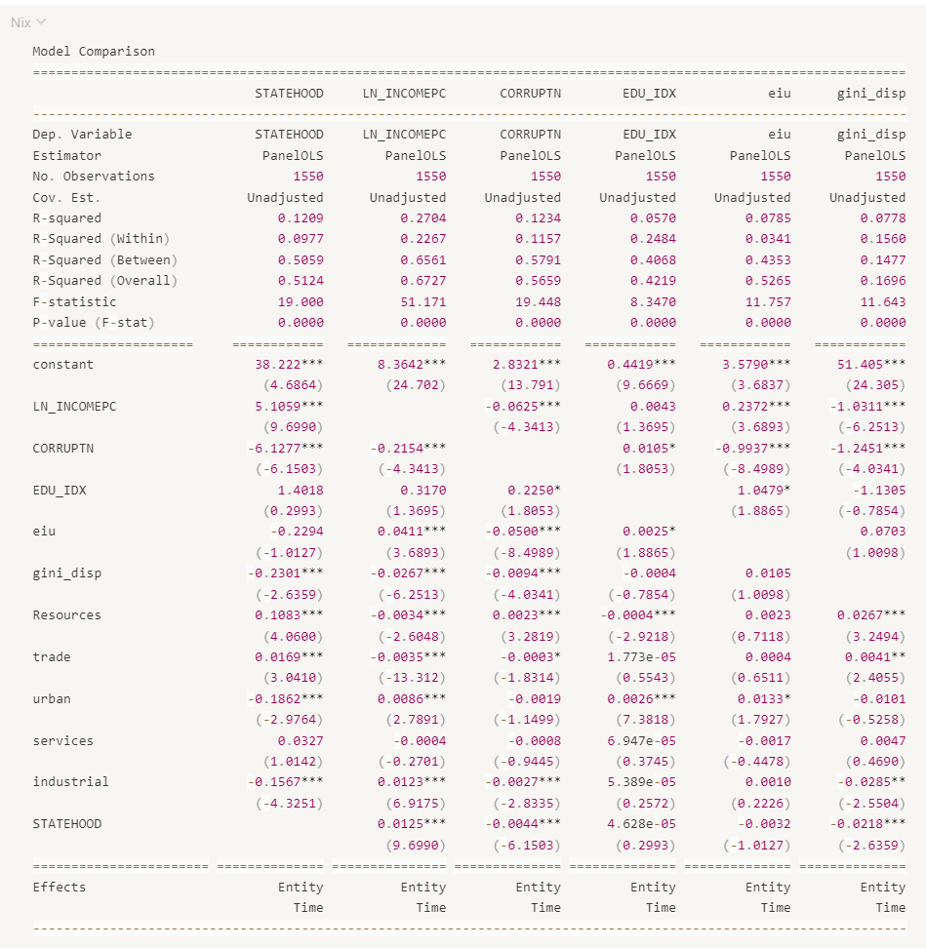